# In class two

Adrian Harris

11/3/2019

### Loading Libraries

```r
library(GGally)
library(gridExtra)
library(gapminder)
library(dplyr)
```

```r
library(ggplot2)
```

# Gapminder Plots

## Explanation

Life expectancy has gone up throughout the years. Highest being from European countries and the lowest being from African countries. In the second plot European countries tend to have a lower population but higher Gdp. There are some Asian countries that have a low population but very high Gdp. From this, you can also see that Asian countries havethe higher populated areas

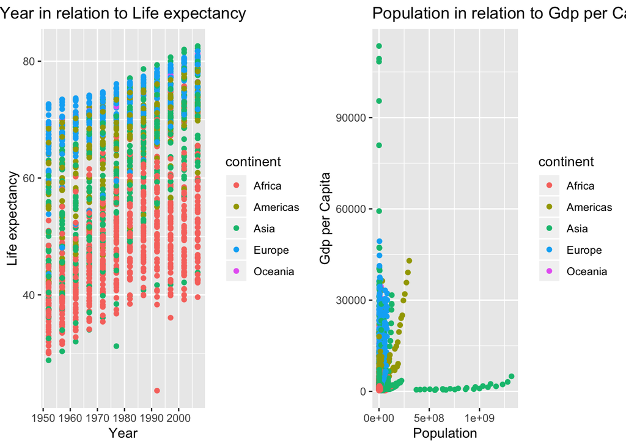

```r
p1 = qplot(x = year,
           y = lifeExp,
           color = continent,
           ylab = "Life expectancy",
           xlab = "Year",
           data = gapminder,
           main = "Year in relation to Life expectancy")+
  theme(plot.title = element_text(hjust = 0.5))
p2 = qplot(x = pop,
           y = gdpPercap,
           color = continent,
           data = gapminder,
           xlab = "Population",
           ylab = "Gdp per Capita",
           main = "Population in relation to Gdp per Capita")

grid.arrange(p1,p2, ncol = 2)
```

# Italian

## Preperation

```r
rest = read.csv("http://vicpena.github.io/sta9750/spring19/nyc.csv")
rest$Location = rest$East
```

# Food vs Price

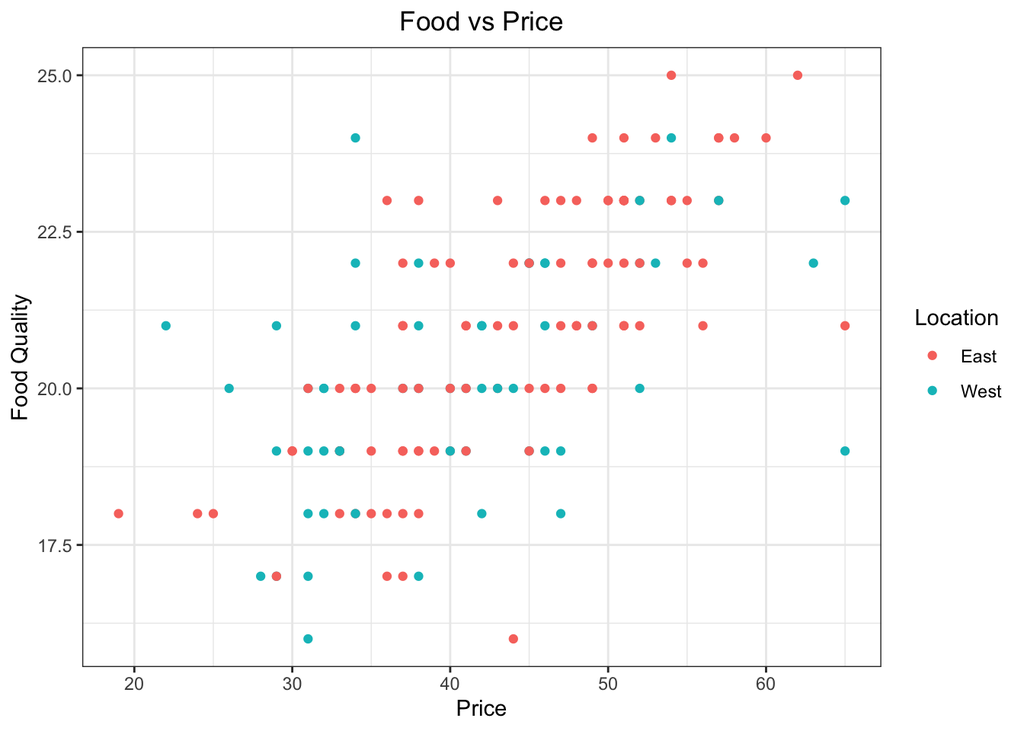

```r
fvp = ggplot(rest)+
  aes(x = Price, y = Food, color = Location)+
  geom_point()+
  theme_bw()+
  ggtitle("Food vs Price")+
  ylab("Food Quality")+
  theme(plot.title = element_text(hjust = 0.5))

fvp
```

# Decor vs Service

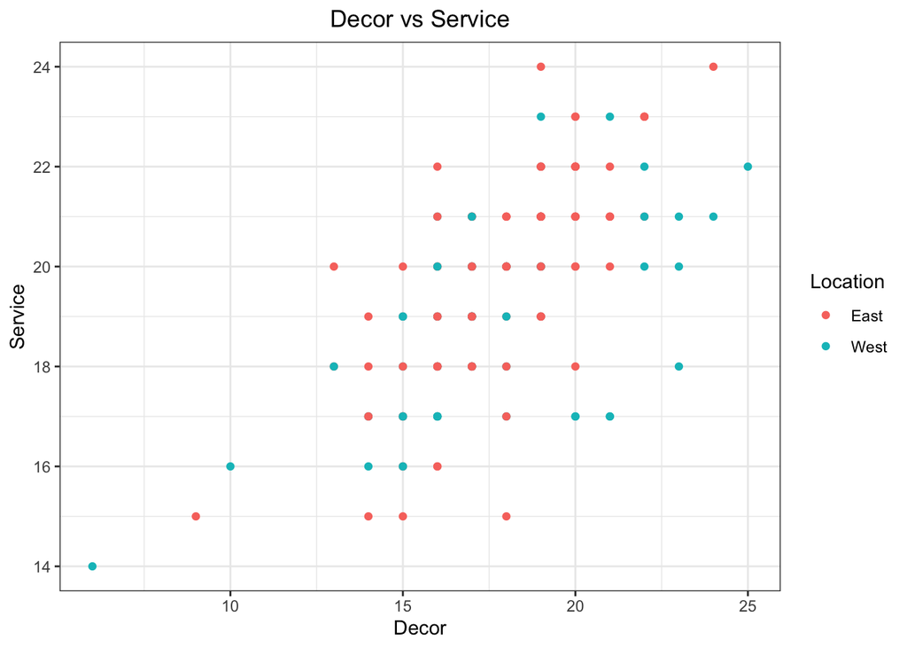

```r
dvs = fvp = ggplot(rest)+
  aes(x = Decor, y = Service, color = Location)+
  geom_point()+
  theme_bw()+
  ggtitle("Decor vs Service")+
  theme(plot.title = element_text(hjust = 0.5))

dvs
```

# Service v Price

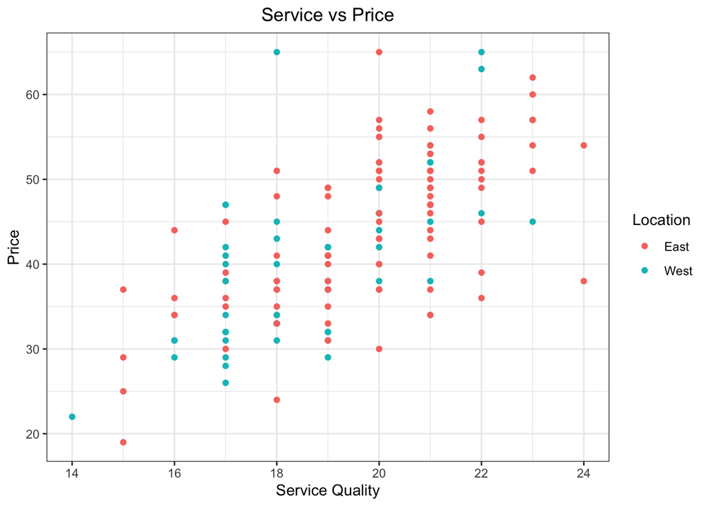

```r
svp = ggplot(rest)+
  aes(x = Service, y = Price,
      color = Location)+
  geom_point()+
  theme_bw()+
  ggtitle("Service vs Price")+
  xlab("Service Quality")+
  theme(plot.title = element_text(hjust = 0.5))

svp
```

# Conclusion

From looking at these plots the data seems to be pretty evenly distributed When I used the ggpairs function you could see that the data is some what linear. The correlation between variables are also positive.

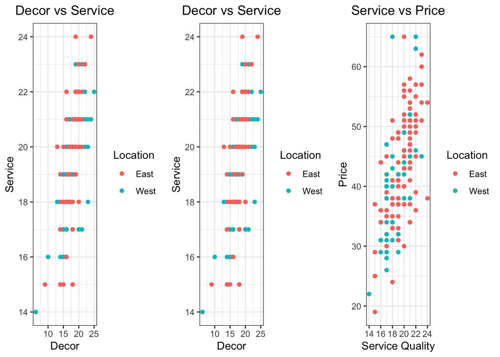

```r
grid.arrange(fvp,dvs,svp, ncol = 3)
```

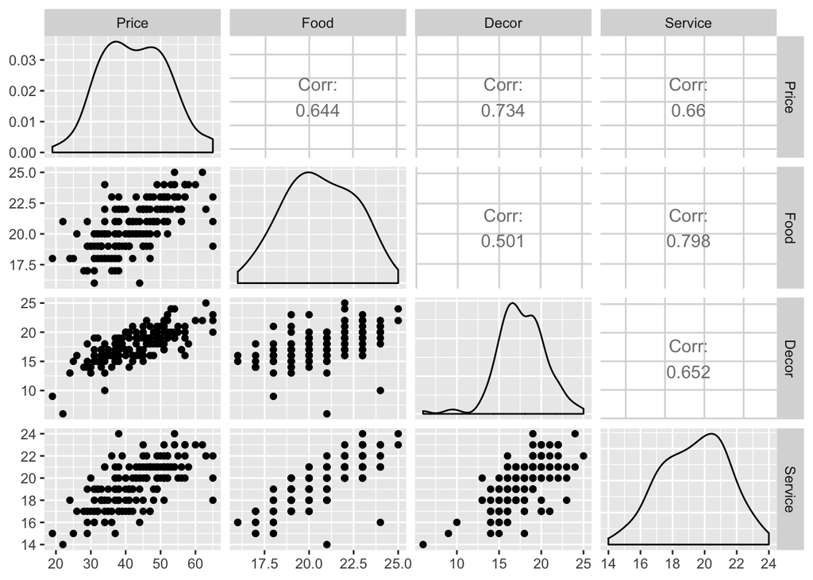

```r
quan = rest %>% select(Price, Food, Decor, Service)
ggpairs(quan)
```

# Heatmap

## Analysis

Service and food have the highest correlation I find with surprising. Maybe when collecting this data the person liked the fast service so this made them enjoy the food better

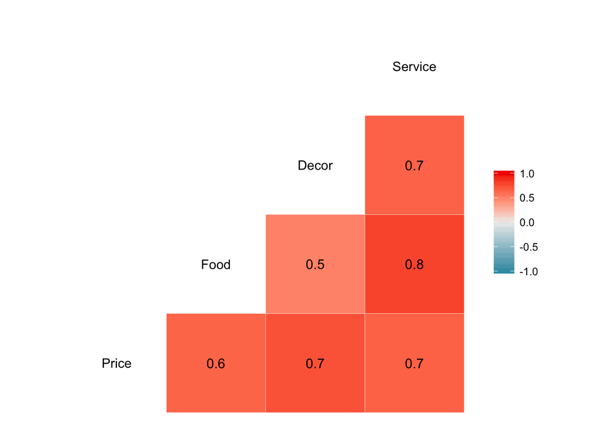

```r
ggcorr(quan, label = T)
```

# Quality

## Analysis

I took them means of both and treated it as a halfway point between high/low and good/bad

```r
mean(rest$Price)
```

```
## [1] 42.62
```

```r
mean(rest$Food)
```

```
## [1] 20.61333
```

```r
lowpricehighqual = rest %>% filter( Price < 42 & Food > 20)
lowpricehighqual
```

```
##    Case          Restaurant Price Food Decor Service East Location
## 1    83            Rughetta    38   23    19      24 East     East
## 2     7              Le Zie    34   22    16      21 West     West
## 3    16      Trattoria Alba    37   21    19      21 East     East
## 4   117            Veronica    22   21     6      14 West     West
## 5   141 Trattoria Del Sogno    29   21    18      19 West     West
## 6    93         Sirabella's    36   23    16      22 East     East
## 7   168             Gennaro    34   24    10      16 West     West
## 8    89             Firenze    41   21    19      21 East     East
## 9    43             Teodora    41   21    17      18 East     East
## 10   59           Via Oreto    40   22    17      20 East     East
## 11    3          Biricchino    34   21    13      18 West     West
## 12    9             Belluno    39   22    19      22 East     East
## 13   71                 Due    37   22    18      20 East     East
## 14  167             Métisse    38   22    17      21 West     West
## 15  149               Bello    38   21    17      20 West     West
## 16   90                Luca    37   21    15      18 East     East
```

```r
highricelowqual = rest %>% filter( Price > 42 & Food < 20)
highricelowqual
```

```
##   Case        Restaurant Price Food Decor Service East Location
## 1  131     Torre di Pisa    47   19    21      17 West     West
## 2  126 Coco Pazzo Teatro    47   18    18      17 West     West
## 3  130     Rainbow Grill    65   19    23      18 West     West
## 4  137        Limoncello    46   19    18      20 West     West
## 5  122        La Rivista    45   19    16      18 West     West
## 6   50        Barbaresco    44   16    16      16 East     East
## 7   11              Fino    45   19    17      20 East     East
```

# Date with Jenny

```r
budget = rest %>% filter(Price < 25)
budget
```

```
##   Case Restaurant Price Food Decor Service East Location
## 1  117   Veronica    22   21     6      14 West     West
## 2   60  Bardolino    24   18    13      18 East     East
## 3  115    Lamarca    19   18     9      15 East     East
```

# Location Plots

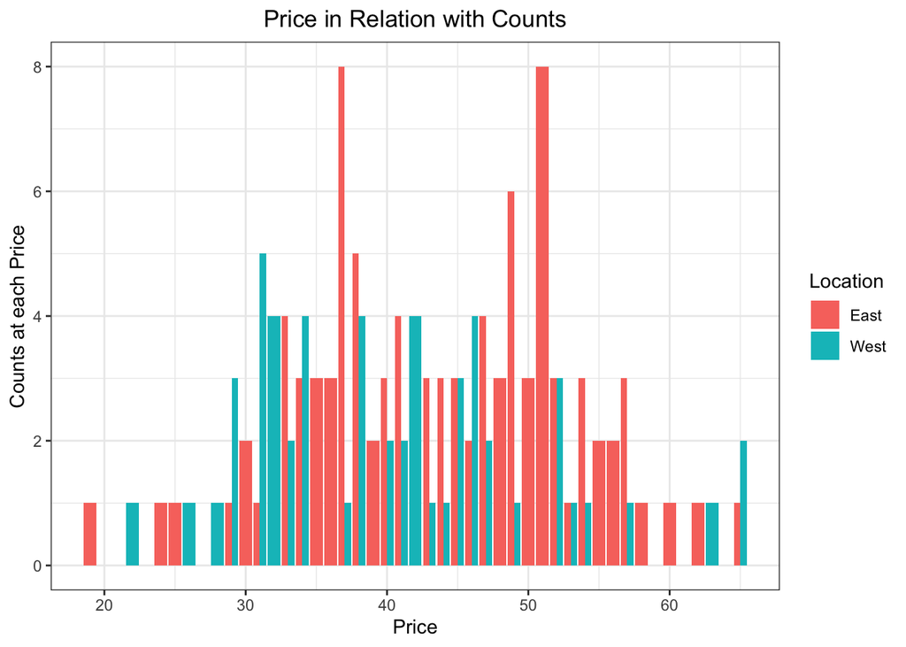

```r
f1 = ggplot(rest)+
  aes(x=Price, fill=Location)+
  geom_bar(position = "dodge")+
  theme_bw()+
  ggtitle("Price in Relation with Counts")+
  ylab("Counts at each Price")+
  theme(plot.title = element_text(hjust = 0.5))

f1
```

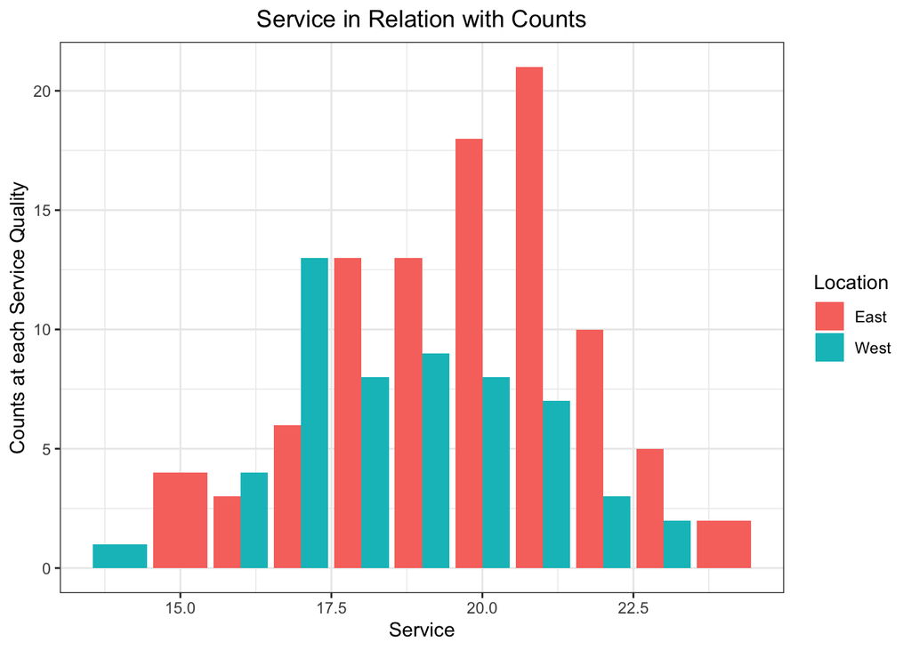

```r
f2 = ggplot(rest)+
  aes(x=Service, fill=Location)+
  geom_bar(position = "dodge")+
  theme_bw()+
  ggtitle("Service in Relation with Counts")+
  ylab("Counts at each Service Quality")+
  theme(plot.title = element_text(hjust = 0.5))

f2
```

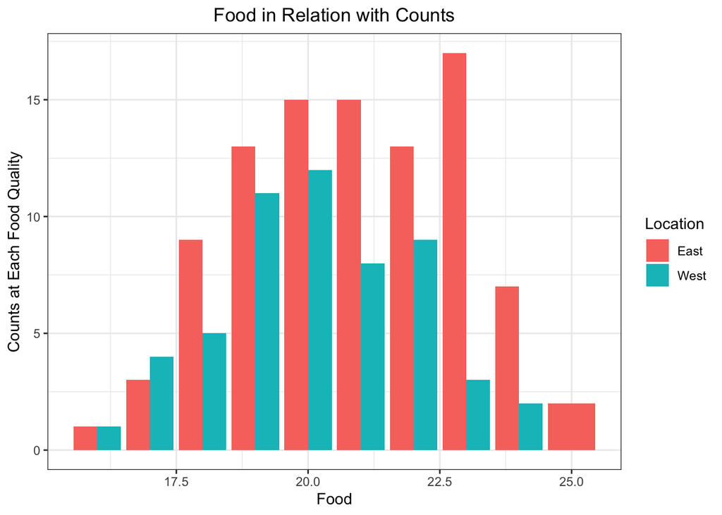

```r
f3 = ggplot(rest)+
  aes(x=Food, fill=Location)+
  geom_bar(position = "dodge")+
  theme_bw()+
  ggtitle("Food in Relation with Counts")+
  ylab("Counts at Each Food Quality")+
  theme(plot.title = element_text(hjust = 0.5))

f3
```

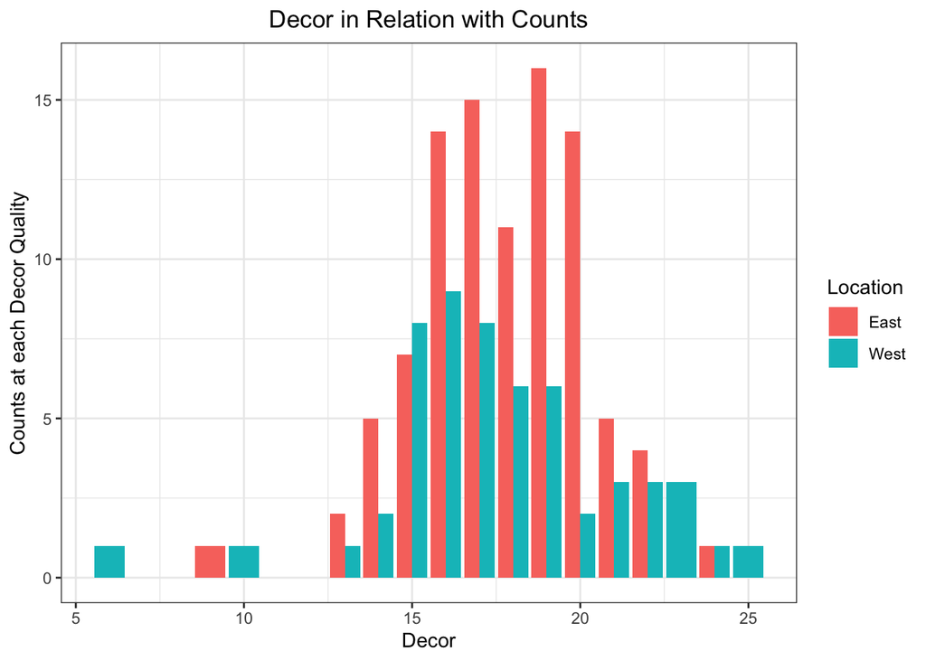

```r
f4 = ggplot(rest)+
  aes(x=Decor, fill=Location)+
  geom_bar(position = "dodge")+
  theme_bw()+
  scale_color_discrete(name = 'Location')+
  ggtitle("Decor in Relation with Counts")+
  ylab("Counts at each Decor Quality")+
  theme(plot.title = element_text(hjust = 0.5))

f4
```

Plot Explanation

Price- more restaurants that have higher prices are in the east

Service - more restaurants have higher service rating are in the east

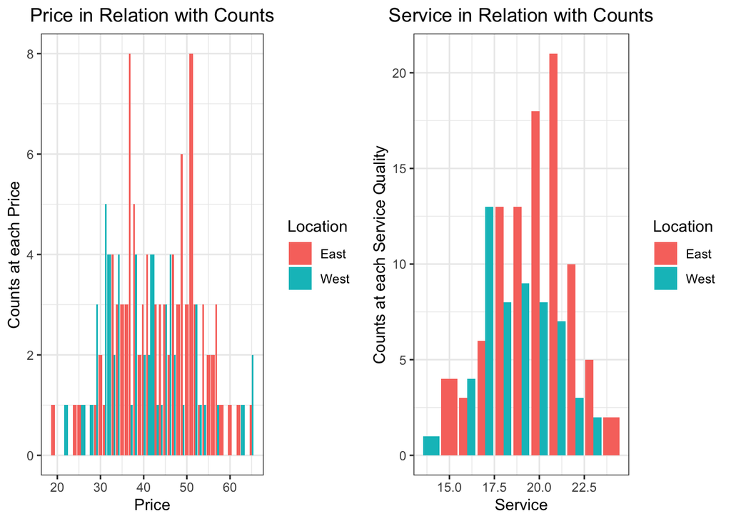

```r
grid.arrange(f1,f2, ncol = 2)
```

Plot Explanation

Food- more restaurants have higher service are in the east

Decor- more restaurants have higher decor are in the east but the west has the highest decor rating

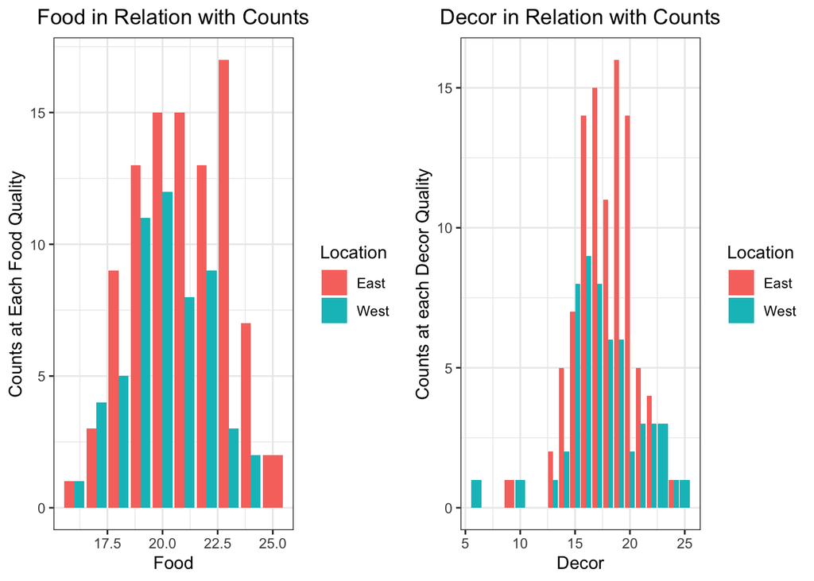

```r
grid.arrange(f3,f4, ncol = 2)
```

Interfaith

```r
inter = read.table("http://users.stat.ufl.edu/~winner/data/interfaith.dat")
colnames(inter) = c("ses","religion","gender","interfaith","count")
inter$ses = factor(inter$ses)
levels(inter$ses) =  c("low","middle", "high")
inter$religion = factor(inter$religion)
levels(inter$religion) = c("protestant", "catholic")
inter$gender = factor(inter$gender)
levels(inter$gender) = c("male","female")
inter$interfaith = factor(inter$interfaith)
levels(inter$interfaith) = c("yes", "no")
inter
```

```
##       ses   religion gender interfaith count
## 1     low protestant   male        yes    11
## 2     low protestant   male         no    23
## 3     low protestant female        yes    15
## 4     low protestant female         no    69
## 5     low   catholic   male        yes    15
## 6     low   catholic   male         no     5
## 7     low   catholic female        yes    19
## 8     low   catholic female         no     3
## 9  middle protestant   male        yes    14
## 10 middle protestant   male         no    26
## 11 middle protestant female        yes    25
## 12 middle protestant female         no    65
## 13 middle   catholic   male        yes     5
## 14 middle   catholic   male         no     5
## 15 middle   catholic female        yes    23
## 16 middle   catholic female         no     5
## 17   high protestant   male        yes     9
## 18   high protestant   male         no    24
## 19   high protestant female        yes    14
## 20   high protestant female         no    58
## 21   high   catholic   male        yes     4
## 22   high   catholic   male         no     2
## 23   high   catholic female        yes    10
## 24   high   catholic female         no     8
```

# Preparation

## Uncounted the counts to get better sense of the counts in the data set

```r
library(tidyr)
inter2 = inter %>% uncount(count)
```

# Plots

## Explanation

### Socioeconomic Status - They intermarry in the middle class the highest. More males tend to intermarry than woman. Catholics tend to intermarry more than protesants

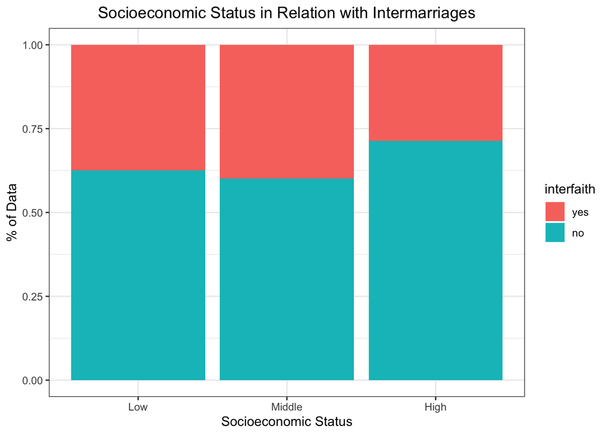

```r
pi1 = ggplot(inter2)+
  aes(x=ses, fill=interfaith)+
  geom_bar(position = "fill")+
  theme_bw()+
  ggtitle("Socioeconomic Status in Relation with Intermarriages")+
  ylab("% of Data")+
  xlab("Socioeconomic Status")+
  theme(plot.title = element_text(hjust = 0.5))+
  scale_x_discrete(labels = c("Low", "Middle","High"))


pi1
```

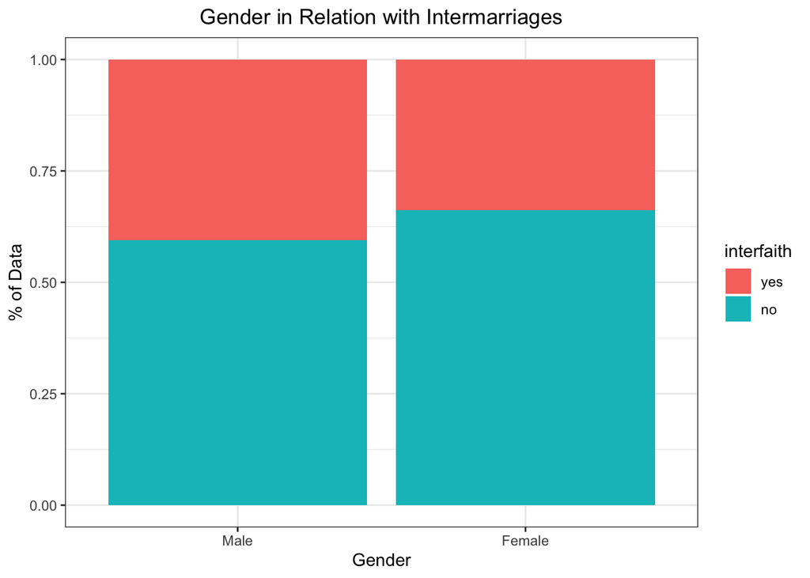

```r
pi2 = ggplot(inter2)+
  aes(x=gender, fill=interfaith)+
  geom_bar(position = "fill")+
  theme_bw()+
  ggtitle("Gender in Relation with Intermarriages")+
  ylab("% of Data")+
  xlab("Gender")+
  theme(plot.title = element_text(hjust = 0.5))+
  scale_x_discrete(labels = c("Male", "Female"))

pi2
```

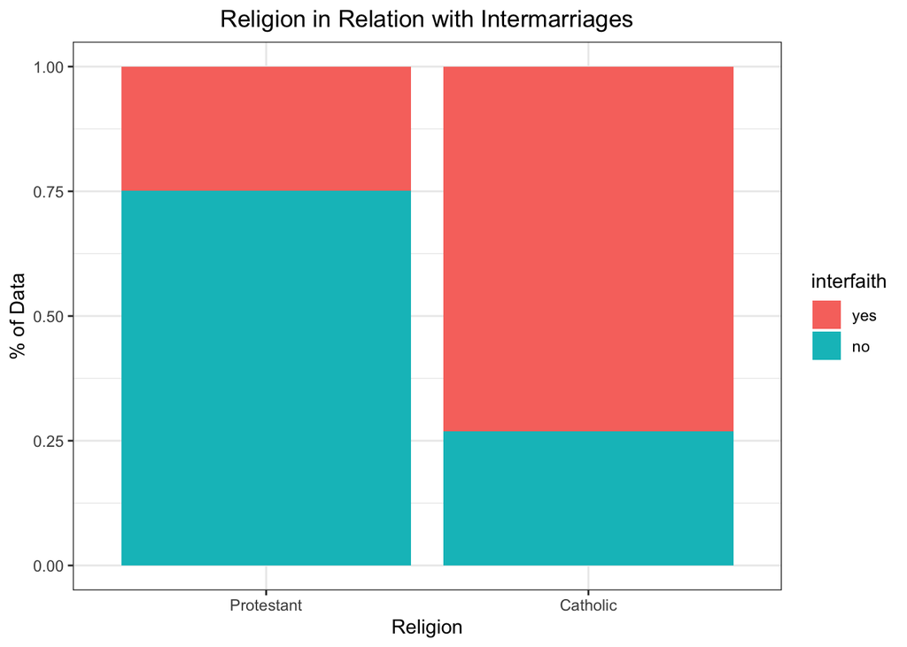

```r
pi3 = ggplot(inter2)+
  aes(x=religion, fill=interfaith)+
  geom_bar(position = "fill")+
  theme_bw()+
  ggtitle("Religion in Relation with Intermarriages")+
  ylab("% of Data")+
  xlab("Religion")+
  theme(plot.title = element_text(hjust = 0.5))+
  scale_x_discrete(labels = c("Protestant", "Catholic"))

pi3
```